# Child Labor Prevalence Across the Latin Americas and Carribean

Rosalina Boyd

2/11/2026

# Introduction

For this project, I will be looking at 3 different functions from my chosen package, **visdat**. I am using the following dataset for thisproject.

[Child Labor Statistics](https://www.kaggle.com/datasets/shaistashahid/child-labor-statistics)

This dataset provides an overview of child labor prevalence across Latin American and Caribbean countries over time. It includes child labor rates (percentage) and estimated numbers of children involved (in millions), categorized by gender and age group.

I will be looking at the following variables:

-**Country( Mexico, Venezuela, Brazil, and Peru).**

-**Gender (Boys and Female)**

-**Child_Labor_rate_percent**

-**Age_Group**

## R packages Used

-**visdat**

-**tidyverse**

I have chosen to use the package **“visdat”** to explore the visualization of an entire dataset. Its good for quick identification of data structure, data types, and potential problems like missing values or unexpected features

I will mainly be working with the following functions in **visdat**.

-**vis_dat**

-**vis_miss**

-**vis_compare**

I have also included **“Tidyverse”**, however, this package is just to enhance the abilites of **“visdat”**. We wont be focused on it for this project.

```r
library(visdat)
library(tidyverse)
```

# Lets Wrangle(Using tidyverse)

### Overall, I want to be able to visualize this data. But first, I have to make sure its ready to be worked with.

Ill begin looking at the data first,

```r
summary(child_labor_statistics_child_labor_statistics_20251214_123456)
```

```
##    Country          Country_Code          Region               Year
##  Length:537         Length:537         Length:537         Min.   :2000
##  Class :character   Class :character   Class :character   1st Qu.:2011
##  Mode  :character   Mode  :character   Mode  :character   Median :2014
##                                                           Mean   :2016
##                                                           3rd Qu.:2023
##                                                           Max.   :2024
##  Child_Labor_Rate_Percent Estimated_Children_Millions    Gender
##  Min.   : 0.40            Min.   :  0.20              Length:537
##  1st Qu.: 5.56            1st Qu.:  2.10              Class :character
##  Median :13.20            Median :  4.65              Mode  :character
##  Mean   :18.47            Mean   : 12.57
##  3rd Qu.:28.50            3rd Qu.: 12.80
##  Max.   :65.35            Max.   :246.00
##   Age_Group
##  Length:537
##  Class :character
##  Mode  :character
##
##
##
```

```r
child_labor_statistics_child_labor_statistics_20251214_123456= child_labor_statistics_child_labor_statistics_20251214_123456 %>%
  mutate(Child_Labor_Rate_Percent=as.numeric(Child_Labor_Rate_Percent))
```

Checking the class

```r
class(child_labor_statistics_child_labor_statistics_20251214_123456$Child_Labor_Rate_Percent)
```

```
## [1] "numeric"
```

Filtering the frame that contains all of my chosen variables.

```r
countries_of_interest=c("Mexico","Venezuela","Brazil","Peru")

MXN_VEN_BRA_PER=child_labor_statistics_child_labor_statistics_20251214_123456 %>%
  filter(Country%in%countries_of_interest)
```

Checking frame

```r
glimpse(MXN_VEN_BRA_PER)
```

```
## Rows: 48
## Columns: 8
## $ Country                     <chr> "Brazil", "Brazil", "Brazil", "Brazil", "M…
## $ Country_Code                <chr> "BRA", "BRA", "BRA", "BRA", "MEX", "MEX", …
## $ Region                      <chr> "Latin America and Caribbean", "Latin Amer…
## $ Year                        <dbl> 2015, 2014, 2013, 2011, 2013, 2011, 2010, …
## $ Child_Labor_Rate_Percent    <dbl> 2.54, 3.53, 3.22, 4.20, 5.61, 6.80, 8.00, …
## $ Estimated_Children_Millions <dbl> 1.27, 1.77, 1.61, 2.10, 2.80, 3.40, 4.00, …
## $ Gender                      <chr> "Total", "Total", "Total", "Total", "Total…
## $ Age_Group                   <chr> "7-14 years", "7-14 years", "7-14 years", …
```

# Lets Visualize(Using Visdat)

### Now that the data is all set up, we can begin looking at a few functions on the visdat package.

First I want look at a visualization of MXN_VEN_BRA_PER data set using **vis_dat()**

-This function displays the data structure and variable classes in a plot

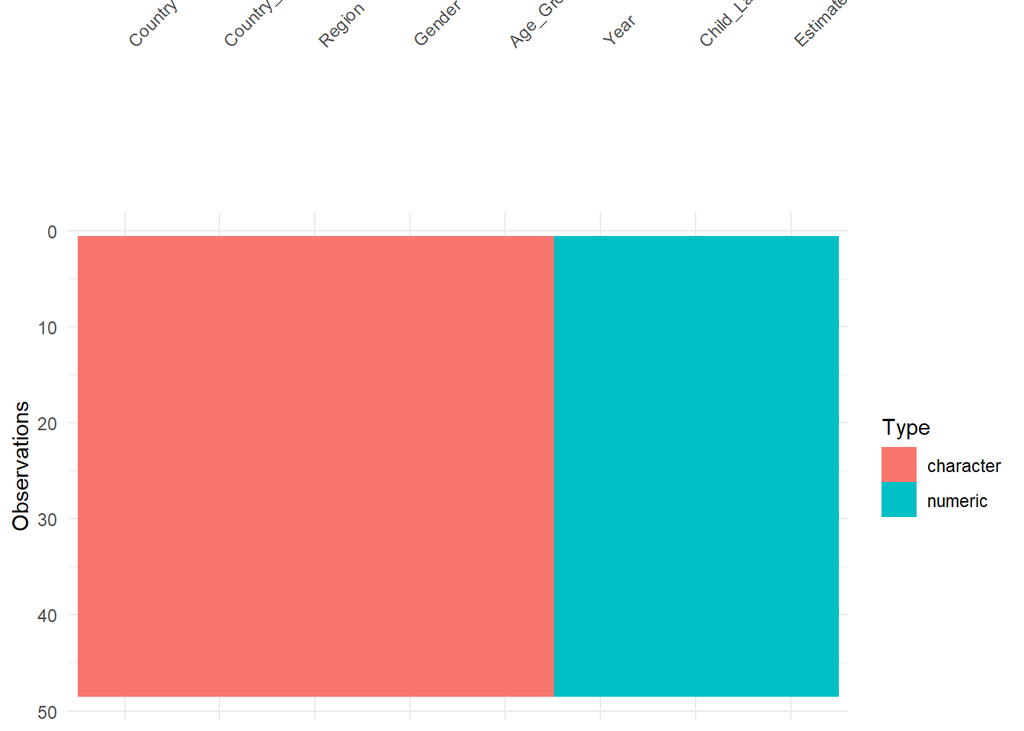

```r
vis_dat(MXN_VEN_BRA_PER)
```

I want to know if there is any missing data so lets check that using **vis_miss**

-This function provides a quick at-a-glance visualization of the location and amount of missing (NA) values within a dataframe.

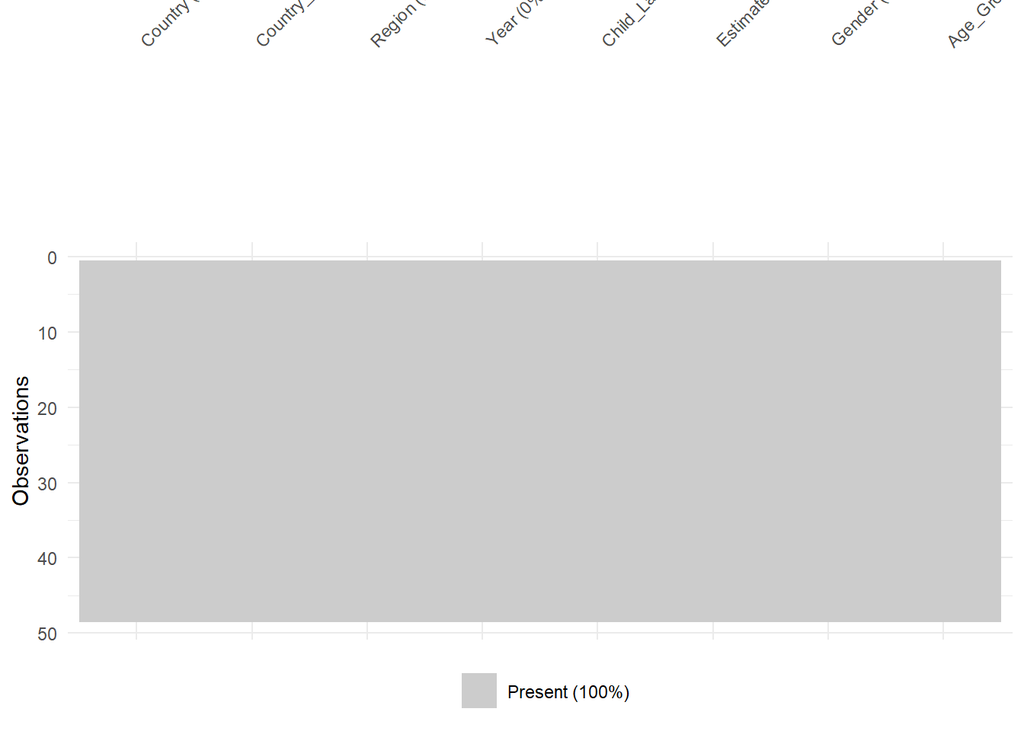

```r
vis_miss(MXN_VEN_BRA_PER)
```

Now that we know there is no missing data, I’ll be fabricating some, just so we can use the **visdat** package to the best of its ability.

To do this, I used tidyverses mutate function, and pipeline operator.

```r
MXN_VEN_BRA_PER_missing=MXN_VEN_BRA_PER %>%
  mutate(Child_Labor_Rate_Percent=ifelse(row_number()%in% c(2, 18, 29, 10, 30, 23, 42), NA, Child_Labor_Rate_Percent))
```

Checking missing values using **vis_dat**

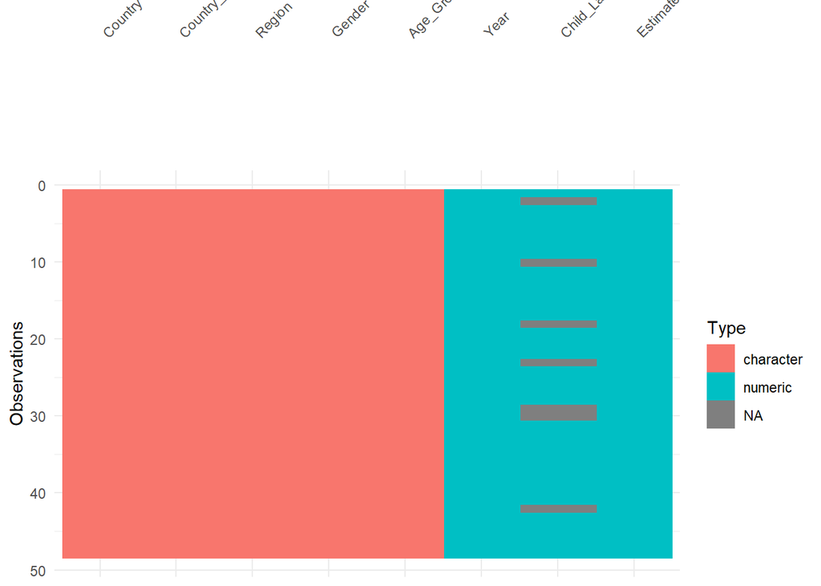

```r
vis_dat(MXN_VEN_BRA_PER_missing)
```

The plot above shows us that R reads this dataset as having characters, numeric, and missing values. Look at the legend labeled “Type” for legend.

Our missing values are found in the numeric variables.

This data is already sorted by type of data in vectors automatically by **visdat**.

Lets *unsort* it for the sake of it using the sort_type function.

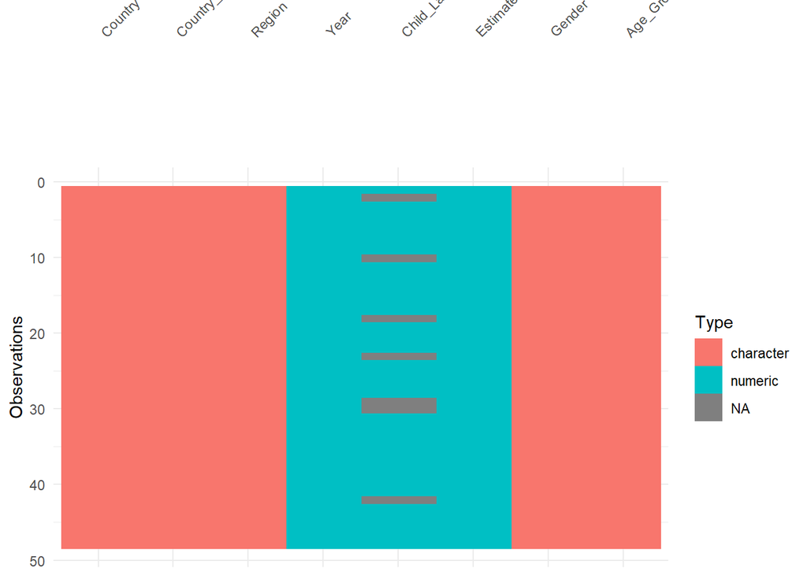

```r
vis_dat(MXN_VEN_BRA_PER_missing, sort_type=FALSE)
```

So now we are missing a few values, lets use **vis_miss**, a function that allows us to look at just data with missing values.

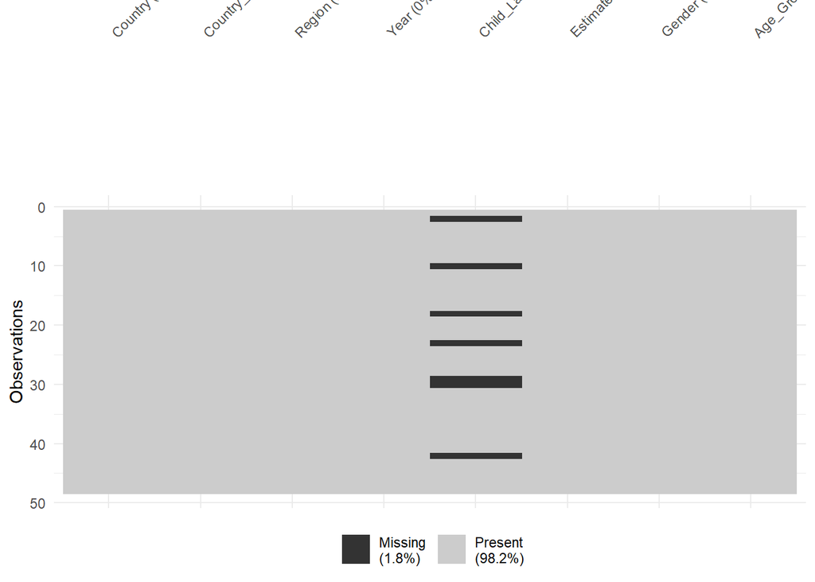

```r
vis_miss(MXN_VEN_BRA_PER_missing)
```

We can also chunk the messy data using **vis_miss**!

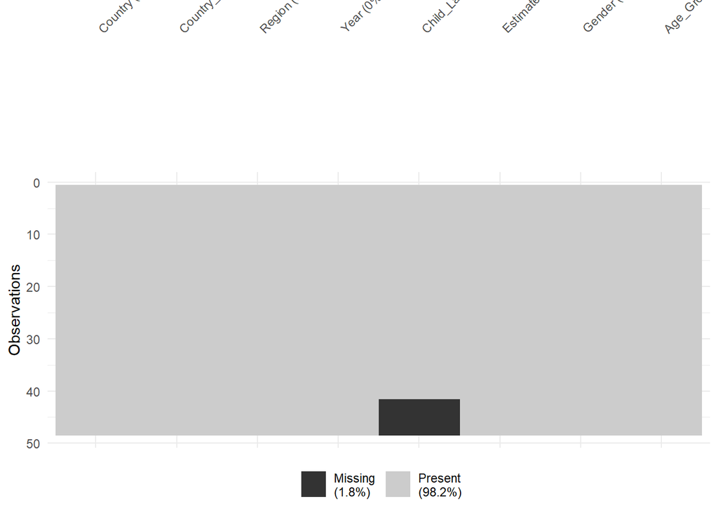

```r
vis_miss(MXN_VEN_BRA_PER_missing, cluster = TRUE)
```

I don’t really want to scroll through all of my code, so I can use **vis_compare** to compare both dataframes, MXN_VEN_BRA_PER (no missing data) and MXN_VEN_BRA_PER_missing (missing data)

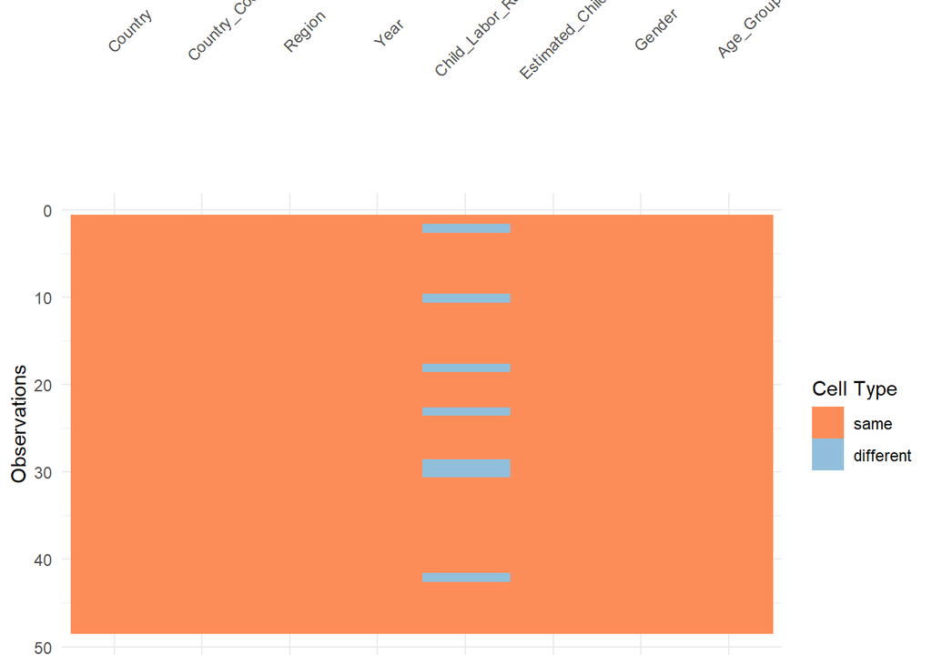

```r
vis_compare(MXN_VEN_BRA_PER_missing, MXN_VEN_BRA_PER)
```

Its the visualization points out the NA values in the dataset as “different”. The data that is not missing is labled as “same” in the Cell Type Legend.

## What I Found Interesting and Useful

Working with the **visdat** package has given me insight into how data scientists quickly assess data quality before diving into analysis.

**What I found most interesting:**

The `vis_dat()` function provides an immediate visualization of an entire dataset’s structure, rather than having to run multiple `class()` or `str()` commands, I can see all variable types at once. This is especially useful when working with large datasets where scrolling through output would be time-consuming.

**What will be useful for my future work:**

The `vis_compare()` function will be super valuable when cleaning data. Instead of manually checking if my code worked correctly, I can visually compare before and after versions. This is would be useful for something like quality control in data.

**Struggles and Difficulties I faced while exploring this package**

After spending some time filtering my data set and preprocessing it, I realized when it was time use **visdat** functions, my data had no missing values, which would have made it difficult to use many of its functions. Therefore, I decided to artifically create my own missing values, just so I could explore the packages functions.

Overall, **visdat** taught me that spending time on data visualization upfront can save hours of debugging later. The package turns tedious data checking into quick, visuals.